# Exploratory Data Analysis

STOR 320.02 Group 8

November 15, 2019

# Creator: Ethan Wu

### Q1: What disease has the most impact on life expectancy?

```r
all = regsubsets(Lifeexpectancy~HepatitisB + Polio + Diphtheria, data=LED.DATA, nbest = 3)
summary(all)
```

```
## Subset selection object
## Call: regsubsets.formula(Lifeexpectancy ~ HepatitisB + Polio + Diphtheria,
##     data = LED.DATA, nbest = 3)
## 3 Variables  (and intercept)
##            Forced in Forced out
## HepatitisB     FALSE      FALSE
## Polio          FALSE      FALSE
## Diphtheria     FALSE      FALSE
## 3 subsets of each size up to 3
## Selection Algorithm: exhaustive
##          HepatitisB Polio Diphtheria
## 1  ( 1 ) " "        " "   "*"
## 1  ( 2 ) " "        "*"   " "
## 1  ( 3 ) "*"        " "   " "
## 2  ( 1 ) " "        "*"   "*"
## 2  ( 2 ) "*"        "*"   " "
## 2  ( 3 ) "*"        " "   "*"
## 3  ( 1 ) "*"        "*"   "*"
```

```r
ShowSubsets(all)
```

```
##          HepatitisB Polio Diphtheria   Rsq adjRsq     Cp
## 1  ( 1 )                           * 13.30  13.26  90.76
## 1  ( 2 )                *            12.80  12.77 104.69
## 1  ( 3 )          *                   6.59   6.55 281.06
## 2  ( 1 )                *          * 16.49  16.42   2.18
## 2  ( 2 )          *     *            13.72  13.64  80.80
## 2  ( 3 )          *                * 13.48  13.41  87.45
## 3  ( 1 )          *     *          * 16.49  16.39   4.00
```

### Q2:Can we predict a country’s status based on its life expectancy?

```r
LED.DATA$Developed = ifelse(LED.DATA$Status == 'Developed', 1, 0)

sinQmod = glm(Developed~Lifeexpectancy, family=binomial, data=LED.DATA)
summary(sinQmod)
```

```
##
## Call:
## glm(formula = Developed ~ Lifeexpectancy, family = binomial,
##     data = LED.DATA)
##
## Deviance Residuals:
##      Min        1Q    Median        3Q       Max
## -2.79015  -0.48124  -0.12473  -0.00981   2.63378
##
## Coefficients:
##                 Estimate Std. Error z value Pr(>|z|)
## (Intercept)    -30.18392    1.39415  -21.65   <2e-16 ***
## Lifeexpectancy   0.38265    0.01814   21.09   <2e-16 ***
## ---
## Signif. codes:  0 '***' 0.001 '**' 0.01 '*' 0.05 '.' 0.1 ' ' 1
##
## (Dispersion parameter for binomial family taken to be 1)
##
##     Null deviance: 2714.3  on 2927  degrees of freedom
## Residual deviance: 1566.9  on 2926  degrees of freedom
##   (10 observations deleted due to missingness)
## AIC: 1570.9
##
## Number of Fisher Scoring iterations: 7
```

Creating a binomial response variable for a countries status.

```r
pred = predict(sinQmod, newdata = LED.DATA, type = "response")
pred = ifelse(pred > 0.5, 1, 0)
accuracy = (length(LED.DATA$Developed) - sum(abs(pred-LED.DATA$Developed), na.rm = TRUE)) / length(LED.DATA$Developed)
accuracy
```

```
## [1] 0.8818924
```

We looked at the prediction accuracy of our model and found that it predicted accurately 88% of the time.

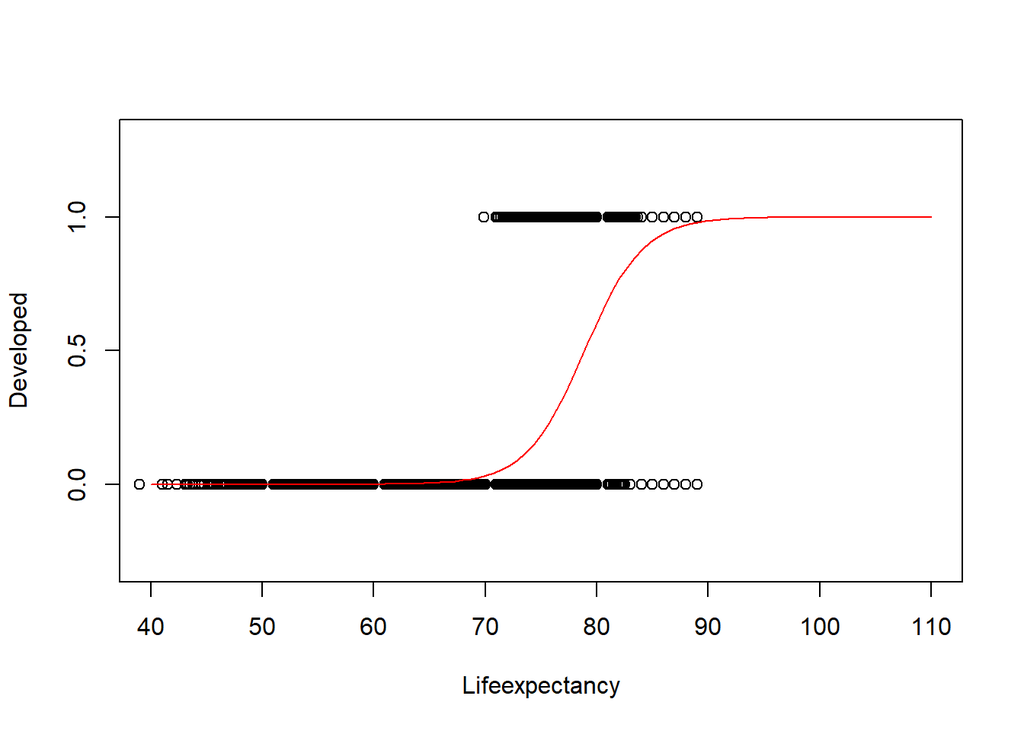

```r
B0 = summary(sinQmod)$coef[1]

B1 = summary(sinQmod)$coef[2]

plot(Developed~Lifeexpectancy, ylim=c(-0.3,1.3), xlim=c(40, 110), data=LED.DATA)

curve(exp(B0+B1*x)/(1+exp(B0+B1*x)),add=TRUE, col="red")
```

# Interpreter: Tanvi Tyagi

### Q1: What is the best classification model for developed vs developing countries using all of the quantitative variables in the data set?

```r
led = read.csv("led.csv")
set.seed(346)
led$SPLIT = sample(x = c("Train","Test"), size = 2938, replace = T, prob = c(0.85,0.15))

ledC = na.omit(led)
drop.cols = c('SPLIT', 'Country', 'Year')
TrainC = ledC %>% filter(SPLIT == "Train") %>% dplyr::select(-c(SPLIT, Country, Year))
TestC = ledC %>% filter(SPLIT == "Test") %>% dplyr::select(-c(SPLIT, Country, Year))
X_TrainC = TrainC %>% dplyr::select(-Status)
Y_TrainC = TrainC%>% dplyr::select(Status)
X_TestC = TestC %>% dplyr::select(-Status)
Y_TestC = TestC %>% dplyr::select(Status)
```

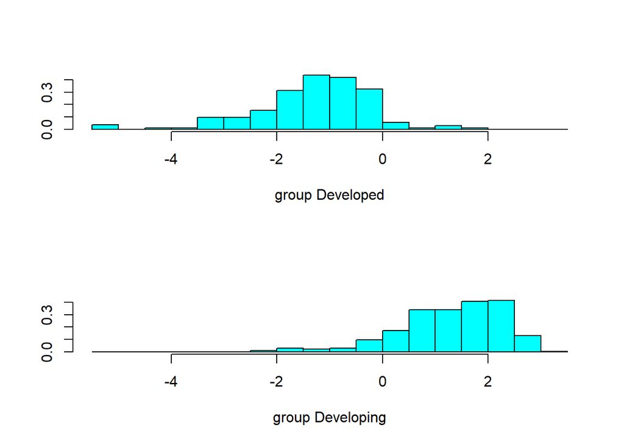

```r
lda.fit = lda(Status~., data = TrainC )
plot(lda.fit)
```

```r
lda.pred = predict(lda.fit, TestC)
lda.class = lda.pred$class
Y_TestC1 = Y_TestC[,1]
table(lda.class, Y_TestC1)
```

```
##             Y_TestC1
## lda.class    Developed Developing
##   Developed         21          6
##   Developing        11        184
```

```r
LDA_Accuracy = mean(lda.class == Y_TestC[,1])
```

K-Nearest Neighbor

```r
X_TrainC1 = as.data.frame(X_TrainC)
Y_TrainC1 = Y_TrainC[,1]
knn.pred = knn(X_TrainC1, X_TestC, Y_TrainC1, k= 1)
Y_TestC1 = Y_TestC[,1]
table(knn.pred, Y_TestC1)
```

```
##             Y_TestC1
## knn.pred     Developed Developing
##   Developed         12         15
##   Developing        20        175
```

```r
KNN_Accuracy = mean(knn.pred == Y_TestC1)
```

As K increases, observations increasingly become classified as developing.

```r
knn.2 = knn(X_TrainC1, X_TestC, Y_TrainC1, k= 2)
knn.38 = knn(X_TrainC1, X_TestC, Y_TrainC1, k= 38)
table(knn.2, Y_TestC1)
```

```
##             Y_TestC1
## knn.2        Developed Developing
##   Developed         11         14
##   Developing        21        176
```

```r
table(knn.38, Y_TestC1)
```

```
##             Y_TestC1
## knn.38       Developed Developing
##   Developed          0          0
##   Developing        32        190
```

Support Vector Machine

```r
classifier = svm(formula = Status~., data = TrainC, type = 'C-classification', kernel = 'linear')
y_pred = predict(classifier, newdata = TestC)
table(Y_TestC[,1], y_pred)
```

```
##             y_pred
##              Developed Developing
##   Developed         23          9
##   Developing         6        184
```

```r
SVM_Accuracy = mean(Y_TestC[,1] == y_pred)
```

```r
Accuracy= data.frame(LDA= LDA_Accuracy, KNN = KNN_Accuracy, SVM = SVM_Accuracy)
```

```r
head(Accuracy)
```

```
##         LDA       KNN       SVM
## 1 0.9234234 0.8423423 0.9324324
```

SVM has the highest accuracy rate with 0.9324324.

### Q2: What is the best model for life expectancy using other quantitative variables?

Ridge Regression

```r
x <- model.matrix(Lifeexpectancy~.,data=led1)[,-1]
y <- led1$Lifeexpectancy
grid.lambda = 10^seq(10, -2, length = 100)
ridge.model = glmnet(x, y, alpha = 0, lambda = grid.lambda)
x1 <- model.matrix(Lifeexpectancy~.,data=Train3)[,-1]
y1 <- Train3$Lifeexpectancy
ridge.model.train = glmnet(x1, y1, alpha = 0, lambda = grid.lambda)
cv.out3 = cv.glmnet(x1, y1, alpha = 0)
best.lambda = cv.out3$lambda.min
ridge.pred <-predict(ridge.model.train, s = best.lambda, newx = X_test2)
mspe.ridge <-mean((ridge.pred-Y_test2)^2)

final.model <-glmnet(x, y, alpha = 0, lambda = best.lambda)
Coef.Ridge <-coef(final.model)[1:19, ]
```

Lasso

```r
lasso.model.train <-glmnet(x, y, alpha = 1, lambda = grid.lambda)
cv.out4 <-cv.glmnet(X_train2, Y_train2, alpha = 1)
best.lambda1 <- cv.out4$lambda.min
lasso.pred <-predict(lasso.model.train, s = best.lambda1, newx = X_test2)
mspe.lasso <-mean((lasso.pred-Y_test2)^2)
final.model1 <-glmnet(x, y, alpha = 1, lambda = best.lambda1)
Coef.Lasso <-coef(final.model1)[1:19,]
```

Elastic Net

```r
EN.model.train = glmnet(X_train2, Y_train2, alpha = 0.5, lambda = grid.lambda)
cv.out5 <-cv.glmnet(X_train2, Y_train2, alpha = 0.5)
best.lambda2 = cv.out5$lambda.min
EN.pred <-predict(EN.model.train, s = best.lambda2, newx = X_train2 )
mspe.EN <-mean((EN.pred-Y_train2)^2)
final.model2 <-glmnet(x, y, alpha = 0.5, lambda = best.lambda)
Coef.EN <-coef(final.model)[1:19,]
```

```r
Coefficients <-data.frame(Ridge = Coef.Ridge, Lasso = Coef.Lasso, Elastic.Net = Coef.EN)
MSPE <-data.frame(Ridge = mspe.ridge, Lasso = mspe.lasso, Elastic.Net = mspe.EN)
```

Coefficients and Mean Square Prediction Error for Ridge, Lasso, and Elastic.Net

```r
Coefficients
```

```
##                                      Ridge         Lasso   Elastic.Net
## (Intercept)                   5.312840e+01  5.304484e+01  5.312840e+01
## AdultMortality               -1.760947e-02 -1.716669e-02 -1.760947e-02
## infantdeaths                  1.657911e-03  6.890983e-02  1.657911e-03
## Alcohol                      -6.525975e-02 -6.210817e-02 -6.525975e-02
## percentageexpenditure         2.727136e-04  3.746698e-04  2.727136e-04
## HepatitisB                   -4.180372e-03 -5.074566e-03 -4.180372e-03
## Measles                       1.206622e-05 -1.518747e-06  1.206622e-05
## BMI                           3.796965e-02  3.406557e-02  3.796965e-02
## under.fivedeaths             -3.600955e-03 -5.256937e-02 -3.600955e-03
## Polio                         1.168601e-02  8.170437e-03  1.168601e-02
## Totalexpenditure              6.960934e-02  7.557653e-02  6.960934e-02
## Diphtheria                    1.935453e-02  1.528224e-02  1.935453e-02
## HIV.AIDS                     -4.172987e-01 -4.382299e-01 -4.172987e-01
## GDP                           3.207480e-05  1.350663e-05  3.207480e-05
## Population                    2.548953e-09  8.281868e-11  2.548953e-09
## thinness1.19years            -3.301806e-02 -1.078416e-02 -3.301806e-02
## thinness5.9years             -2.674348e-02 -4.159852e-02 -2.674348e-02
## Incomecompositionofresources  1.006295e+01  9.950185e+00  1.006295e+01
## Schooling                     8.029257e-01  8.827781e-01  8.029257e-01
```

```r
MSPE
```

```
##      Ridge    Lasso Elastic.Net
## 1 11.42345 10.95943    13.15747
```

The Lasso model has the lowest mean square prediction error.

# Orator: Alexander Pinder

### Q1: What is the distribution of life expectancy across different countries?

```r
LED.DATA.MAP <- LED.DATA %>%
  filter(Year == 2015) %>%
  dplyr::select(Country, Lifeexpectancy)
LED.DATA.MAP
```

```
## # A tibble: 183 x 2
##    Country             Lifeexpectancy
##    <chr>                        <dbl>
##  1 Afghanistan                   65
##  2 Albania                       77.8
##  3 Algeria                       75.6
##  4 Angola                        52.4
##  5 Antigua and Barbuda           76.4
##  6 Argentina                     76.3
##  7 Armenia                       74.8
##  8 Australia                     82.8
##  9 Austria                       81.5
## 10 Azerbaijan                    72.7
## # ... with 173 more rows
```

```r
matched <- joinCountryData2Map(LED.DATA.MAP, joinCode = "NAME", nameJoinColumn = "Country")
```

```
## 179 codes from your data successfully matched countries in the map
## 4 codes from your data failed to match with a country code in the map
## 64 codes from the map weren't represented in your data
```

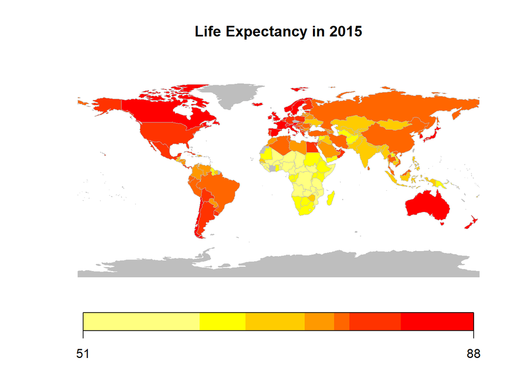

```r
mapCountryData(matched, nameColumnToPlot = "Lifeexpectancy", mapTitle = "Life Expectancy in 2015", colourPalette = "heat", missingCountryCol = "grey")
```

### Q2: Which factors are most correlated with life expectancy?

```r
da1=filter(LED.DATA,Status=='Developing')
da2=filter(LED.DATA,Status=='Developed')
da1.plot=ggplot(da1,aes(Country,Lifeexpectancy,fct_reorder(Country,Lifeexpectancy)))+geom_point()+geom_smooth()+theme(axis.text.x = element_text(angle = 45, hjust = 1))
da2.plot=ggplot(da2,aes(Country,Lifeexpectancy,fct_reorder(Country,Lifeexpectancy)))+geom_point()+geom_smooth()+theme(axis.text.x = element_text(angle = 45, hjust = 1))
```

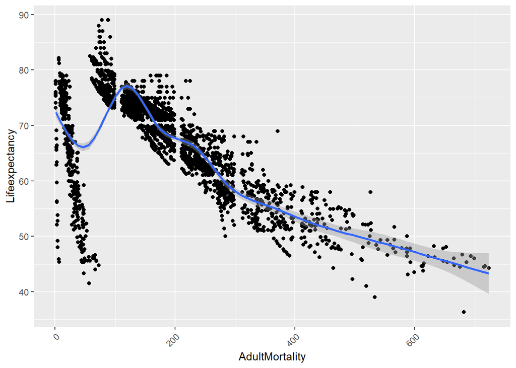

```r
mort.da1=ggplot(da1,aes(AdultMortality,Lifeexpectancy,fct_reorder(AdultMortality,Lifeexpectancy)))+geom_point()+geom_smooth()+theme(axis.text.x = element_text(angle = 45, hjust = 1))
mort.da2=ggplot(da2,aes(AdultMortality,Lifeexpectancy,fct_reorder(AdultMortality,Lifeexpectancy)))+geom_point()+geom_smooth()+theme(axis.text.x = element_text(angle = 45, hjust = 1))
inf.da1=ggplot(da1,aes(infantdeaths,Lifeexpectancy,fct_reorder(infantdeaths,Lifeexpectancy)))+geom_point()+geom_smooth()+theme(axis.text.x = element_text(angle = 45, hjust = 1))
inf.da2=ggplot(da2,aes(infantdeaths,Lifeexpectancy,fct_reorder(infantdeaths,Lifeexpectancy)))+geom_point()+geom_smooth()+theme(axis.text.x = element_text(angle = 45, hjust = 1))
alc.da1=ggplot(da1,aes(Alcohol,Lifeexpectancy,fct_reorder(Alcohol,Lifeexpectancy)))+geom_point()+geom_smooth()+theme(axis.text.x = element_text(angle = 45, hjust = 1))
alc.da2=ggplot(da2,aes(Alcohol,Lifeexpectancy,fct_reorder(Alcohol,Lifeexpectancy)))+geom_point()+geom_smooth()+theme(axis.text.x = element_text(angle = 45, hjust = 1))
measles.da1=ggplot(da1,aes(Measles,Lifeexpectancy,fct_reorder(Measles,Lifeexpectancy)))+geom_point()+geom_smooth()+theme(axis.text.x = element_text(angle = 45, hjust = 1))
measles.da2=ggplot(da2,aes(Measles,Lifeexpectancy,fct_reorder(Measles,Lifeexpectancy)))+geom_point()+geom_smooth()+theme(axis.text.x = element_text(angle = 45, hjust = 1))
gdp.da1=ggplot(da1,aes(GDP,Lifeexpectancy,fct_reorder(GDP,Lifeexpectancy)))+geom_point()+geom_smooth()+theme(axis.text.x = element_text(angle = 45, hjust = 1))
gdp.da2=ggplot(da2,aes(GDP,Lifeexpectancy,fct_reorder(GDP,Lifeexpectancy)))+geom_point()+geom_smooth()+theme(axis.text.x = element_text(angle = 45, hjust = 1))
bmi.da1=ggplot(da1,aes(BMI,Lifeexpectancy,fct_reorder(BMI,Lifeexpectancy)))+geom_point()+geom_smooth()+theme(axis.text.x = element_text(angle = 45, hjust = 1))
bmi.da2=ggplot(da2,aes(BMI,Lifeexpectancy,fct_reorder(BMI,Lifeexpectancy)))+geom_point()+geom_smooth()+theme(axis.text.x = element_text(angle = 45, hjust = 1))
school.da1=ggplot(da1,aes(Schooling,Lifeexpectancy,fct_reorder(Schooling,Lifeexpectancy)))+geom_point()+geom_smooth()+theme(axis.text.x = element_text(angle = 45, hjust = 1))
school.da2=ggplot(da2,aes(Schooling,Lifeexpectancy,fct_reorder(Schooling,Lifeexpectancy)))+geom_point()+geom_smooth()+theme(axis.text.x = element_text(angle = 45, hjust = 1))
mort.da1
```

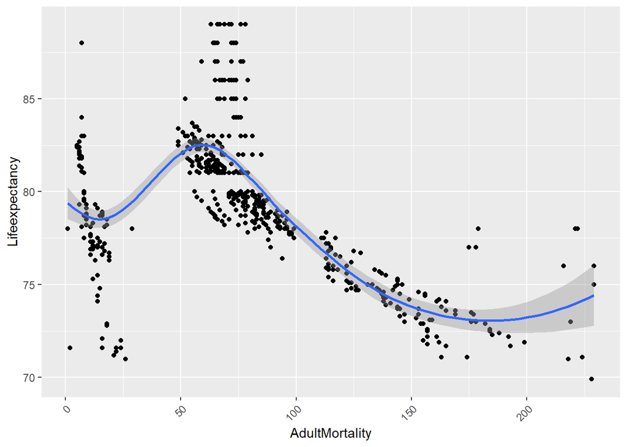

```r
mort.da2
```

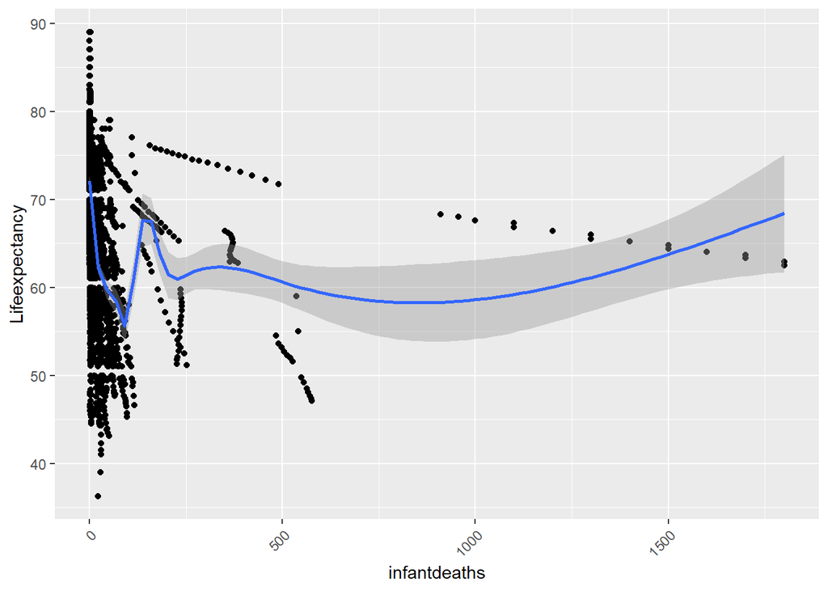

```r
inf.da1
```

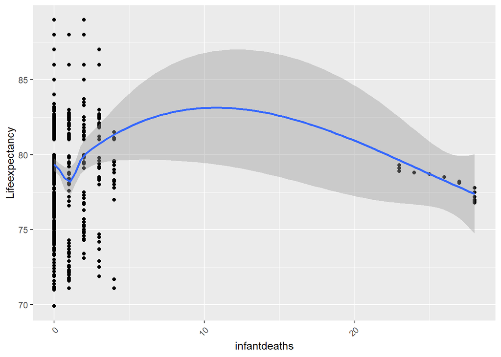

```r
inf.da2
```

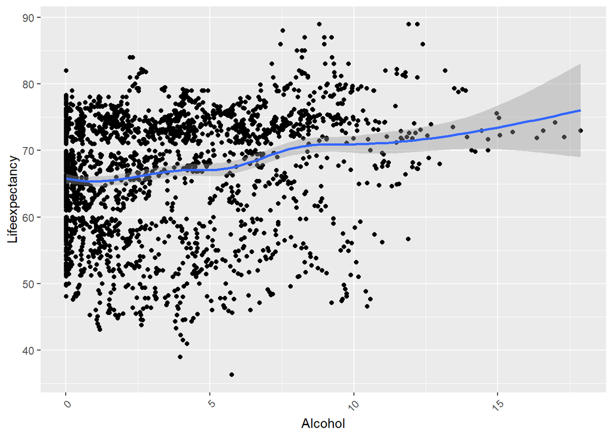

```r
alc.da1
```

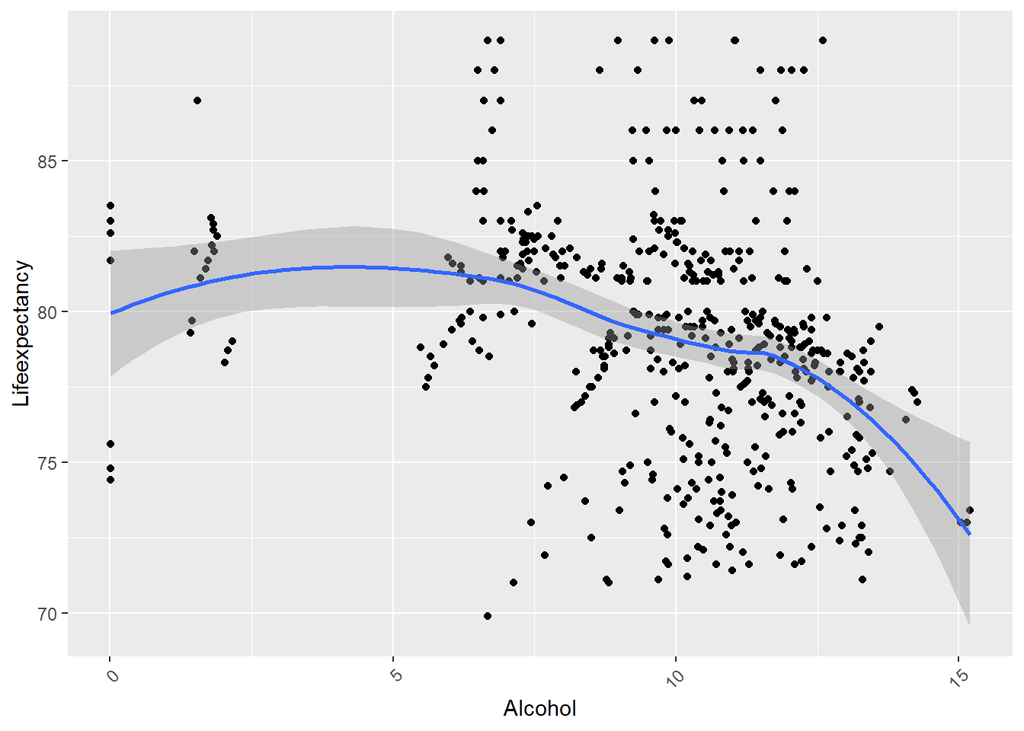

```r
alc.da2
```

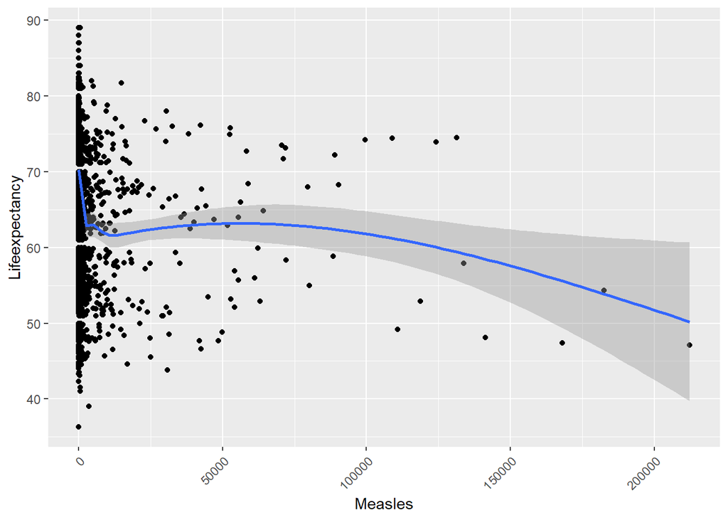

```r
measles.da1
```

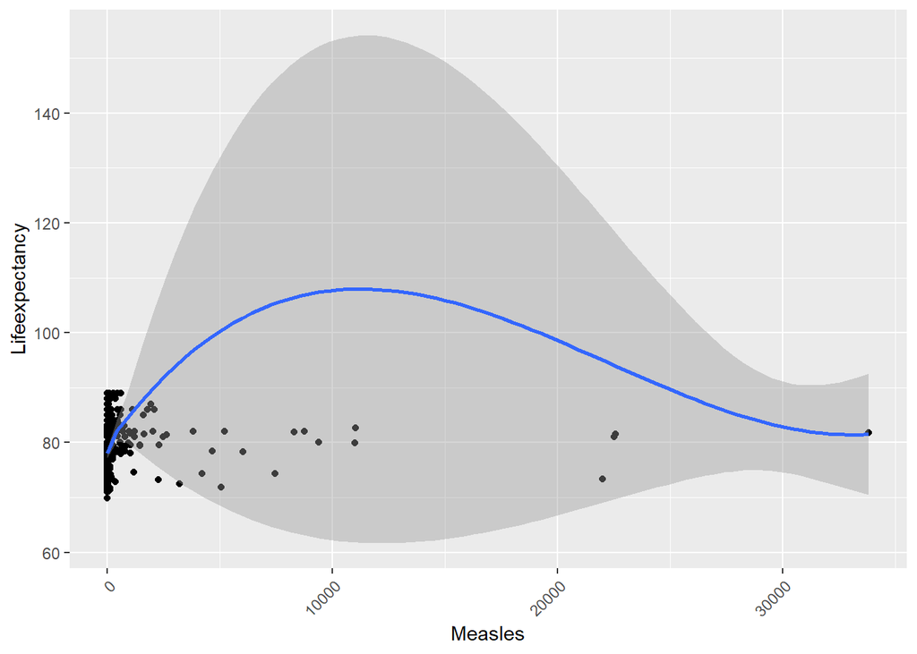

```r
measles.da2
```

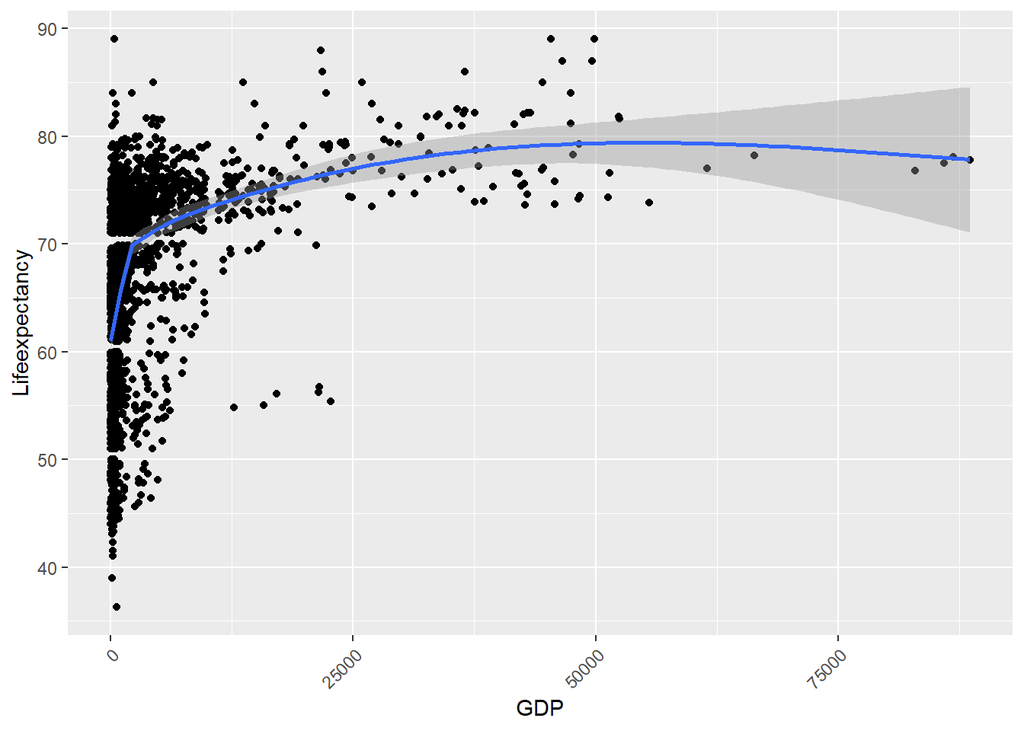

```r
gdp.da1
```

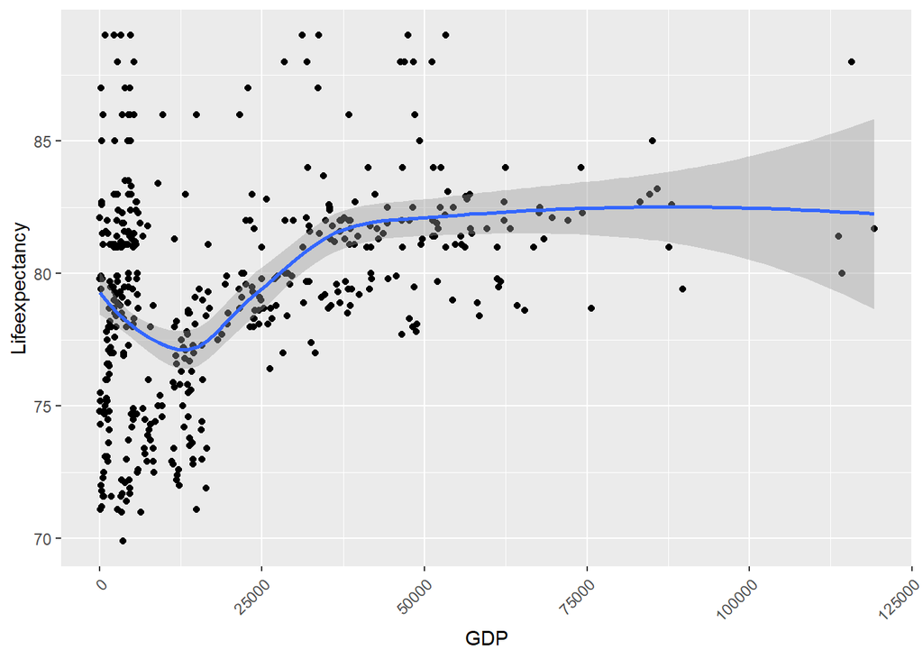

```r
gdp.da2
```

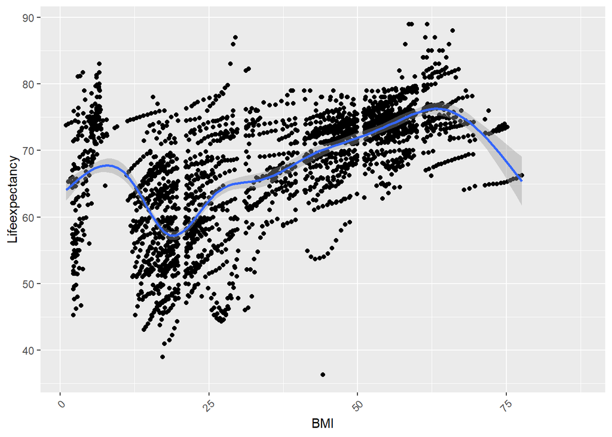

```r
bmi.da1
```

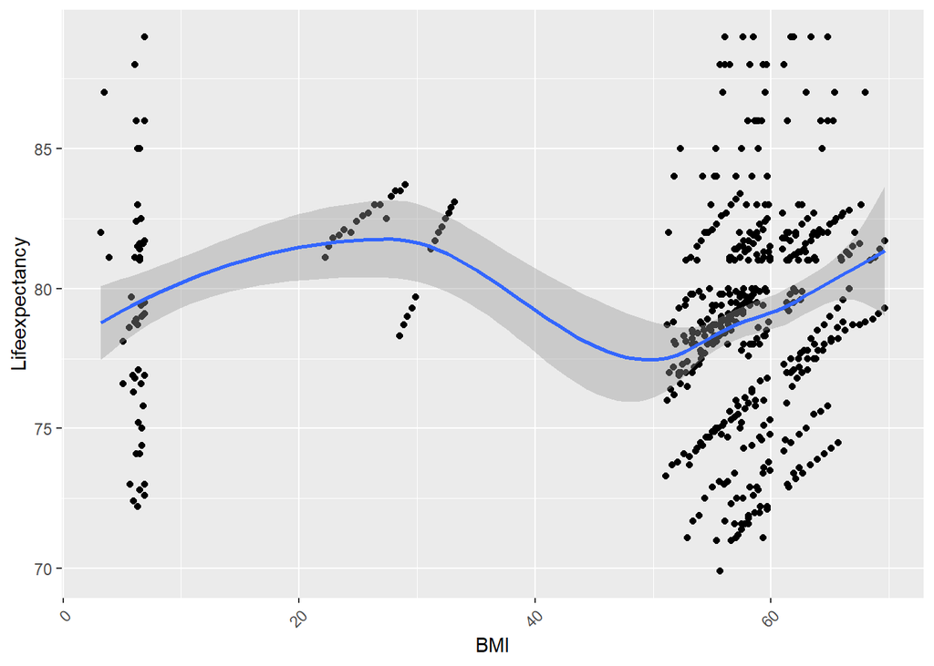

```r
bmi.da2
```

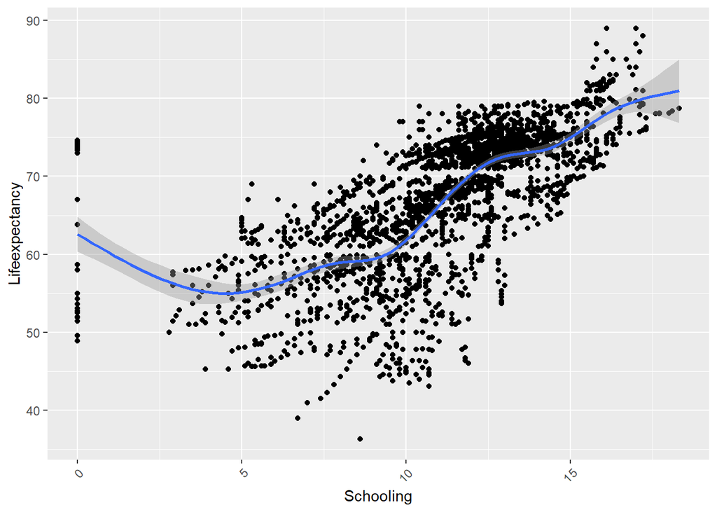

```r
school.da1
```

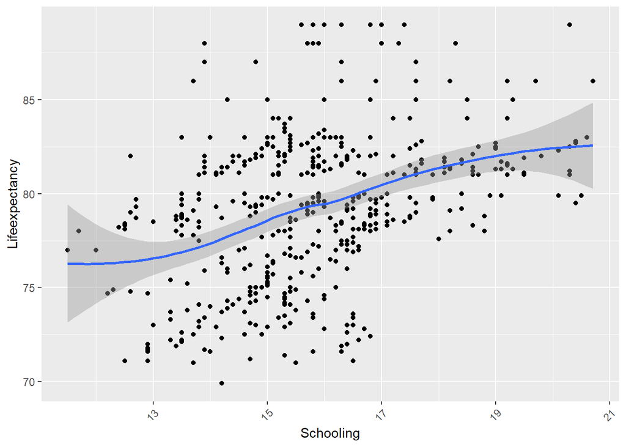

```r
school.da2
```

# Deliverer: Alison Tedford

### Q1: How has mean life expectancy changed over the past 15 years for developing vs developed countries?

```r
q1.data <- LED.DATA %>%
  filter(is.na(Lifeexpectancy) == FALSE) %>% #na value was causing part of graph to not show up
  group_by(Status, Year) %>%
  summarize(
    mean = mean(Lifeexpectancy)
  )

print(q1.data)
```

```
## # A tibble: 32 x 3
## # Groups:   Status [2]
##    Status     Year  mean
##    <chr>     <dbl> <dbl>
##  1 Developed  2000  76.8
##  2 Developed  2001  77.1
##  3 Developed  2002  77.5
##  4 Developed  2003  77.9
##  5 Developed  2004  78.4
##  6 Developed  2005  78.6
##  7 Developed  2006  79.1
##  8 Developed  2007  79.3
##  9 Developed  2008  78.9
## 10 Developed  2009  79.6
## # ... with 22 more rows
```

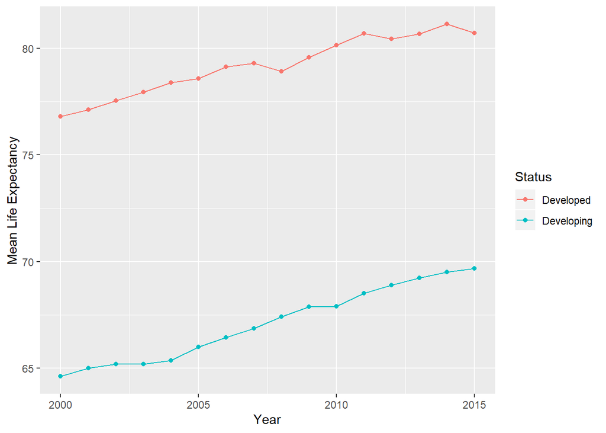

```r
ggplot(q1.data, aes(Year, mean, color = Status)) + geom_point() + geom_line() + labs(y = "Mean Life Expectancy")
```

### Q2: Has the mean life expectancy for each continent changed significantly over time?

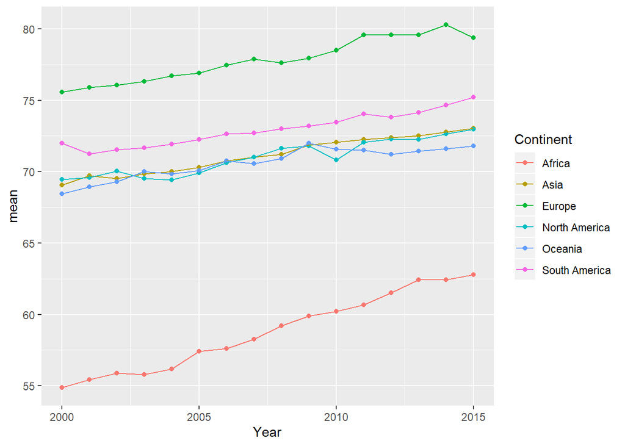

```r
web.table = xml2::read_html("http://www.geonames.org/countries/")
Continent.DATA = web.table %>%
  html_table(fill = T) %>%
  .[[2]] %>%
 dplyr::select(Country, Continent) %>%
  mutate(Country = ifelse(Country == "DR Congo", "Congo, Democratic Republic of", Country), )

q2.data <- left_join(LED.DATA, Continent.DATA, by = "Country") %>%
filter(is.na(Lifeexpectancy) == FALSE) %>% #graph gets gaps in it without this line
  mutate(Continent = ifelse(is.na(Continent)==TRUE, "North America", Continent),
        Continent = ifelse(Continent == "AF", "Africa", Continent),
        Continent = ifelse(Continent == "AS", "Asia", Continent),
        Continent = ifelse(Continent == "EU", "Europe", Continent),
         Continent = ifelse(Continent == "OC", "Oceania", Continent),
         Continent = ifelse(Continent == "AF", "Africa", Continent),
         Continent = ifelse(Continent == "SA", "South America", Continent)
         ) %>%
  group_by(Continent, Year) %>%
  summarize(
    mean = mean(Lifeexpectancy)
    )

ggplot(q2.data, aes(Year, mean, color = Continent)) + geom_point() + geom_line()
```